# APEC 8601: Natural Resource Economics

Problem Set 1

Author

Matt Braaksma

## 1 Conrad and Clark 2.10.2

Compute the MSY and corresponding effort levels for the following two examples, using the Schaefer model. Also find the level of effort just sufficient to drive the populations to extinction.

1. Antarctic baleen whales: $r = .05$ per year, $K = 400,000$ BWU (bluewhale units), $q = 1.6 \times 10^3$ per whale-catcher year.

**Answer**

For the logistic growth function, $F'(X)=0$ at:
$$Y_{MSY}=\frac{rK}{4}=(0.05)(400000)/4= 5000 \text{ BWU/yr}$$

Then substitute $Y_{MSY}=\frac{rK}{4}, X_{MSY}=\frac{K}{2}$ into the the sustained-yield function for the Schaefer model:
$$\begin{aligned}
Y_{MSY} &= qEX_{MSY} \\
\frac{rK}{4} &= qE\frac{K}{2} \\
E &= \frac{r}{2q} \\
E &= \frac{(0.05)}{2(0.0016)} \\
E_{MSY} &= 15.625
\end{aligned}$$

If the relative rate of harvest $qE$ exceeds the intrinsic growth rate of the population $r$, then the population will be driven to extinction.
$$E_{ext} = \frac{r}{q} = \frac{0.05}{0.0016} = 31.25$$

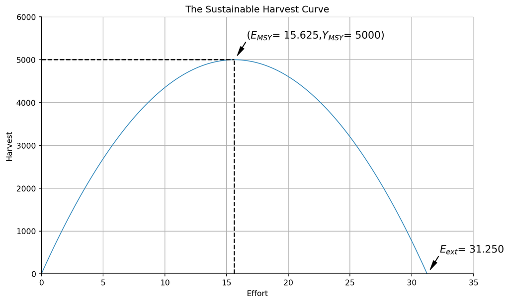

```python
r = .05
K = 400000
q = 0.0016

# generate all possible values of stocks
S=np.arange(1,K + 1).reshape((K,1))

# find growth for each stock size
dSdt = r * S * ( 1- S / K)
effort_ss = (r * S * (1 - S/K))/(q * S)
y_msy = r*K/4
e_msy = (r)/(2*q)
e_ext = (r)/(q)

# plot harvest as a function of stocks
plt.figure(figsize=(10, 6))
plt.subplot(111)
lw = 1
plt.plot(effort_ss,dSdt,lw=lw, c="#348ABD")
plt.plot((0, e_msy), (y_msy, y_msy), 'k--')
plt.plot((e_msy, e_msy), (0, y_msy), 'k--')
plt.annotate('($E_{MSY}$= %1.3f,$Y_{MSY}$= %i)' %(e_msy, y_msy), xy=(e_msy+.25, 5100), xytext=(e_msy+1, 5500),
            arrowprops=dict(facecolor='black',width=.3,headwidth=5),fontsize=13)
plt.annotate('$E_{ext}$= %1.3f' %e_ext, xy=(e_ext+.25, 100), xytext=(e_ext+1, 500),
            arrowprops=dict(facecolor='black',width=.3,headwidth=5),fontsize=13)
plt.xlabel("Effort")
plt.ylabel("Harvest")
plt.title("The Sustainable Harvest Curve")
plt.xlim(0,35)
plt.ylim(0,6000)
sbn.despine()
plt.grid()
```

2. Pacific yellowfin tuna: $r = 2.6$ per year, $K = 250,000$ metric tons, $q = 3.8 \times 10^5$ per standard fishing day (SFD).

**Answer**

For the logistic growth function, $F'(X)=0$ at:
$$Y_{MSY}=\frac{rK}{4}=(2.6)(250000)/4= 162500 \text{ BWU/yr}$$

From part (a) we know,
$$E_{MSY} = \frac{r}{2q} = \frac{2.6}{2(0.000038))} = 34210.526$$

If the relative rate of harvest $qE$ exceeds the intrinsic growth rate of the population $r$, then the population will be driven to extinction.
$$E_{ext} = \frac{r}{q} = \frac{2.6}{0.000038} = 68421.053$$

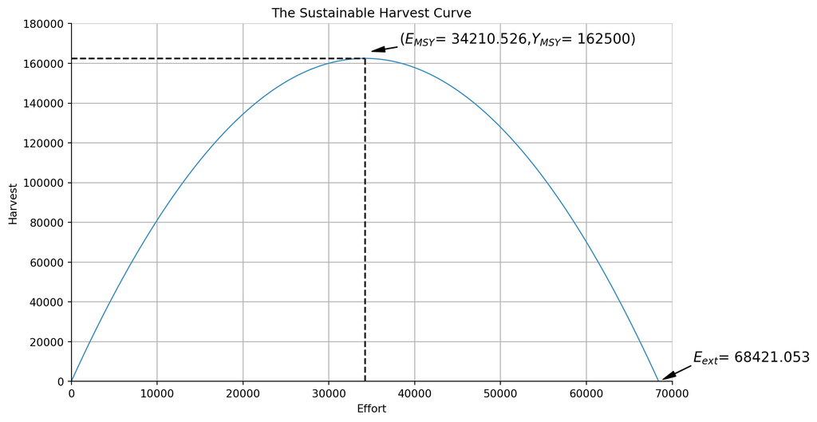

```python
r = 2.6
K = 250000
q = 0.000038

# generate all possible values of stocks
S=np.arange(1,K + 1).reshape((K,1))

# find growth for each stock size
dSdt = r * S * ( 1- S / K)
effort_ss = (r * S * (1 - S/K))/(q * S)
y_msy = r*K/4
e_msy = (r)/(2*q)
e_ext = (r)/(q)

# plot harvest as a function of stocks
plt.figure(figsize=(10, 6))
plt.subplot(111)
lw = 1
plt.plot(effort_ss,dSdt,lw=lw, c="#348ABD")
plt.plot((0, e_msy), (y_msy, y_msy), 'k--')
plt.plot((e_msy, e_msy), (0, y_msy), 'k--')
plt.annotate('($E_{MSY}$= %1.3f,$Y_{MSY}$= %i)' %(e_msy, y_msy), xy=(e_msy+800, 166000), xytext=(e_msy+4000, 170000),
            arrowprops=dict(facecolor='black',width=.3,headwidth=5),fontsize=13)
plt.annotate('$E_{ext}$= %1.3f' %e_ext, xy=(e_ext+500, 1000), xytext=(e_ext+4000, 10000),
            arrowprops=dict(facecolor='black',width=.3,headwidth=5),fontsize=13)
plt.xlabel("Effort")
plt.ylabel("Harvest")
plt.title("The Sustainable Harvest Curve")
plt.xlim(0,70000)
plt.ylim(0,180000)
sbn.despine()
plt.grid()
```